# STAT 331: Final Project

Author

Ethan Handelman, Maxwell Dubow, Aaron Eliscu

## Setup

```r
library(tidyverse)
library(knitr)
library(kableExtra)
library(ggplot2)
library(plotly)
library(gganimate)
library(gifski)
library(png)
library(countrycode)
library(broom)

life_expectancy <- read_csv("Data/lex.csv")
coal_per_cap <- read_csv("Data/coal_consumption_per_cap.csv",
           na = c("NA", ""))
```

## Pivoting/Joining the Data

```r
life_expectancy <- life_expectancy |>
  pivot_longer(cols = 2:last_col(),
    names_to = "year",
    values_to = "infant_lex") |>
  drop_na(infant_lex)

coal_per_cap <- coal_per_cap |>
  mutate(across(.cols = 2:last_col(), as.double)) |>
  pivot_longer(cols = 2:last_col(),
               names_to = "year",
               values_to = "coal_cons_per_cap") |>
  drop_na(coal_cons_per_cap)

lex_coal <- coal_per_cap |>
  left_join(life_expectancy, by = c("country", "year")) |>
  filter(!is.na(coal_cons_per_cap), !is.na(infant_lex)) |>
  mutate(year = as.integer(year),
         continent = countrycode(sourcevar = country,
                                 origin    = "country.name",
                                 destination = "continent"))
```

## Data Description

In this investigative report we will be exploring the relationship between two quantitative variables across countries/years:

- **Coal consumption per capita (measured in tonnes oil equivalent)**

  Source: [BP Statistical Review](https://www.bp.com/statisticalreview)
- **Infant life expectancy**

  Source: [Gapminder](https://www.gapminder.org/data/documentation/gd004/)

The data on coal consumption per capita comes from BP Statistical Review’s report on global energy markets over time. The data we are interested in is the amount of coal consumption per country per year. The data set, which we downloaded from Gapminder contains countries as observations and coal consumption in a specific year as variables. We transformed the data so that coal consumption was the only variable and each observation was a country and year.

The data on infant life expectancy comes from Gapminder’s own data collection from various different sources. It contains information on the life expectancy at birth in each country and year. The data set, which we downloaded from Gapminder contains countries as observations and infant life expectancy in a specific year as variables. We transformed the data so that life expectancy was the only variable and each observation was a country and year.

Finally, we combined these two data sets so that for each observation (country and year), we had coal consumption and infant life expectancy as our two variables. There were a few missing values in the data, which we ignored in our analysis.

## Data Visualization

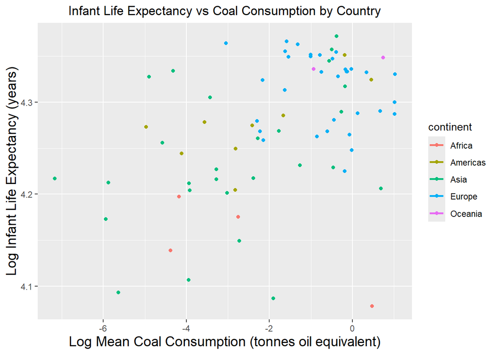

```r
lex_coal_cont <- lex_coal |>
  filter(!is.na(coal_cons_per_cap), !is.na(infant_lex)) |>

  group_by(continent, country) |>
  summarize(mean_coal = mean(coal_cons_per_cap),
            mean_infant = mean(infant_lex),
            .groups = "drop") |>
  filter(mean_coal != 0 & mean_infant != 0) |>
  mutate(log_mean_coal = log(mean_coal),
         log_mean_infant = log(mean_infant))

lex_coal_cont|>
  ggplot(mapping = aes(x = log_mean_coal,
                       y = log_mean_infant,
                       label = country,
                       color = continent,
                       text = paste0("<b>Country:</b> ",
                                     country,
                                     "<br>"))) +
  geom_point() +
  geom_smooth(method = "lm", se = F) +
  # geom_text(check_overlap = TRUE) +
  labs(x = "Log Mean Coal Consumption (tonnes oil equivalent)",
       y = "Log Infant Life Expectancy (years)",
       title = "Infant Life Expectancy vs Coal Consumption by Country") + theme(axis.title = element_text(size = 14),
                                                                                plot.title = element_text(hjust = 0.5))
```

```r
ggplotly(p, tooltip = "text")
```

[output not shown]

```
Error: object 'p' not found
```

```r
p_anim <- ggplot(lex_coal, aes(x = coal_cons_per_cap, y = infant_lex)) +
  geom_point(alpha = 0.7, size = 2, color = "#2c3e50") +
  # For raw‐scale axes, comment these out;
  # for log log, uncomment them:
  # scale_x_continuous(trans = "log10") +
  # scale_y_continuous(trans = "log10") +
  labs(
    title = "Infant Life Expectancy vs. Coal Consumption",
    subtitle = "Year: {frame_time}",
    x = "Coal Consumption per Capita (tonnes oil equivalent)",
    y = "Infant Life Expectancy (years)"
  ) +
  scale_color_brewer(palette = "Dark2") +
  theme_minimal(base_size = 14) +
  theme(
    plot.subtitle = element_text(size = 16, face = "bold"),
    legend.position = "right"
  ) +
  transition_time(year) +
  ease_aes("linear")

anim <- animate(
  p_anim,
  nframes = length(unique(lex_coal$year)) * 5,
  fps = 10,
  width = 800,
  height = 600,
  renderer = gifski_renderer(loop = TRUE)
)
```

[output not shown]

```r
anim
```

```
Error: object 'anim' not found
```

```r
anim_save("coal_infant_by_continent.gif", animation = anim)
```

```
Error: object 'anim' not found
```

[figure not shown]

Animated Relationship

## Linear Regression Model

```r
model <- lm(log_mean_infant ~ log_mean_coal, data = lex_coal_cont)

coefs <- broom::tidy(model)

knitr::kable(
  coefs,
  digits  = 3,
  caption = "Regression Coefficients\n(log Mean Infant Life Expectancy ∼ log Mean Coal Consumption)",
  col.names = c("Term", "Estimate", "Std. Error", "t value", "p value")
) |>
  kableExtra::kable_styling(full_width = FALSE, bootstrap_options = c("striped", "hover"))
```

Regression Coefficients (log Mean Infant Life Expectancy ∼ log Mean Coal Consumption)

| Term | Estimate | Std. Error | t value | p value |
| --- | --- | --- | --- | --- |
| (Intercept) | 4.304 | 0.010 | 417.595 | 0 |
| log_mean_coal | 0.017 | 0.004 | 4.329 | 0 |

## References

Crimmins, Eileen M. 2015. “Lifespan and Healthspan: Past, Present, and Promise.” *The Gerontologist* 55 (6): 901–11. https://doi.org/10.1093/geront/gnv130.

Gasparotto, Juciano, and Kátia Da Boit Martinello. 2021. “Coal as an Energy Source and Its Impacts on Human Health.” *Energy Geoscience* 2 (2): 113–20. https://doi.org/10.1016/j.engeos.2020.07.003.